# Monitoramento Funil Blend4

## Execução

```
Última execução: 17/07/2026 11:52:04 -03
```

## Diretório e Configurações

## Base: Blend4 em Produção

```
Volume total (simulação): 66,363
Contratos únicos: 66,363
Período: 2026-07-01 00:00:00 → 2026-07-16 00:00:00
```

## Diário e Semanal

```
Diário simulação: 2026-07-09 00:00:00 → 2026-07-16 00:00:00 | n=31,122
```

```
Semanal simulação: 2026-07-01 00:00:00 → 2026-07-16 00:00:00 | n=63,881
```

## Multiproponente vs. Uniproponente

Proporção de Multipronentes vs. Uniproponentes ao longo das semanas. O esperado é algo entre 3-4%.

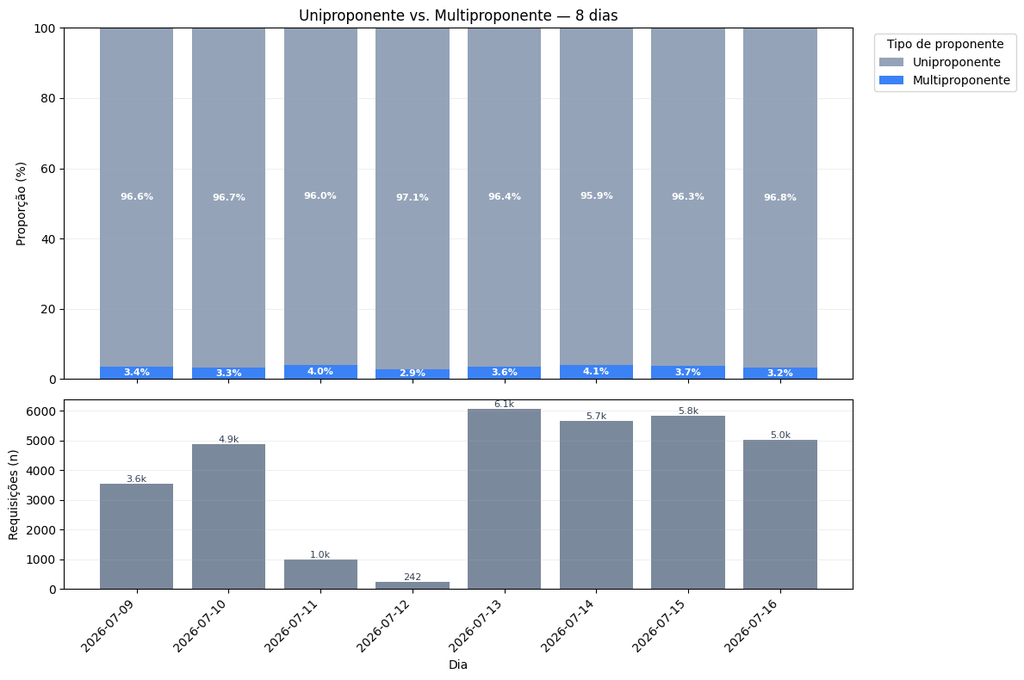

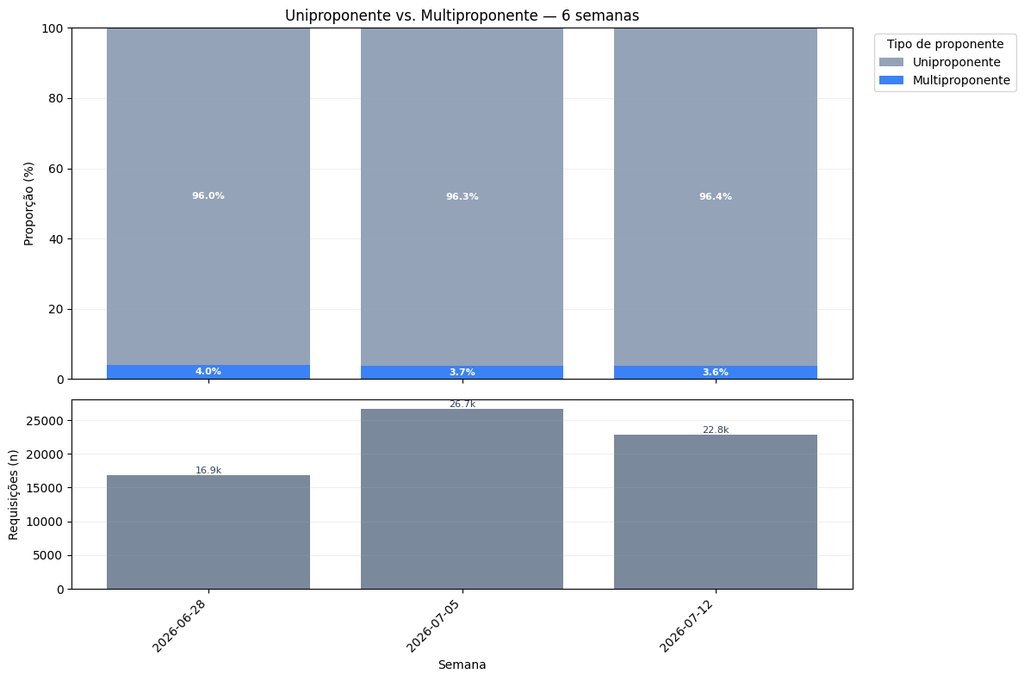

# Uniproponentes

A partir daqui, seguimos apenas com o público Uniproponente.

## Mix de Modelos Diário e Semanal

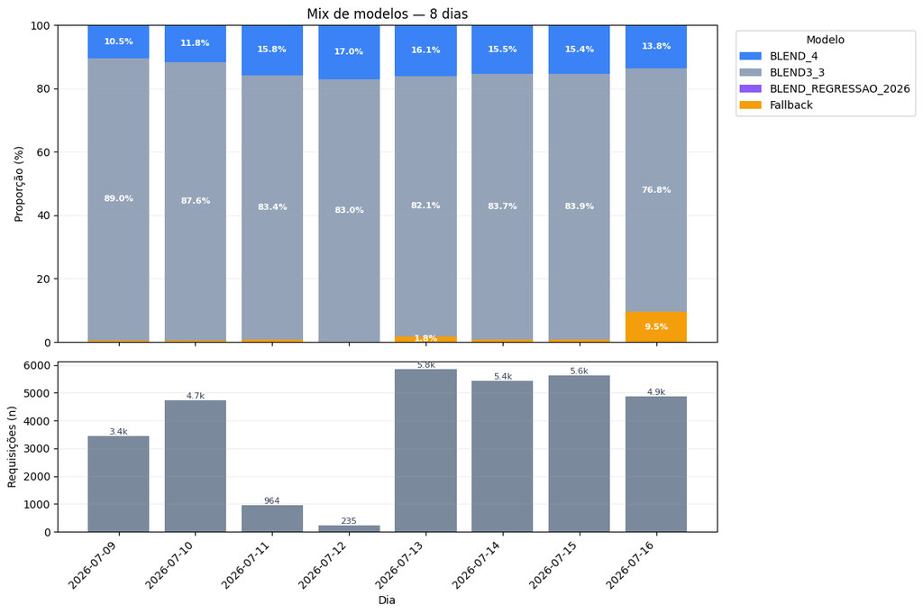

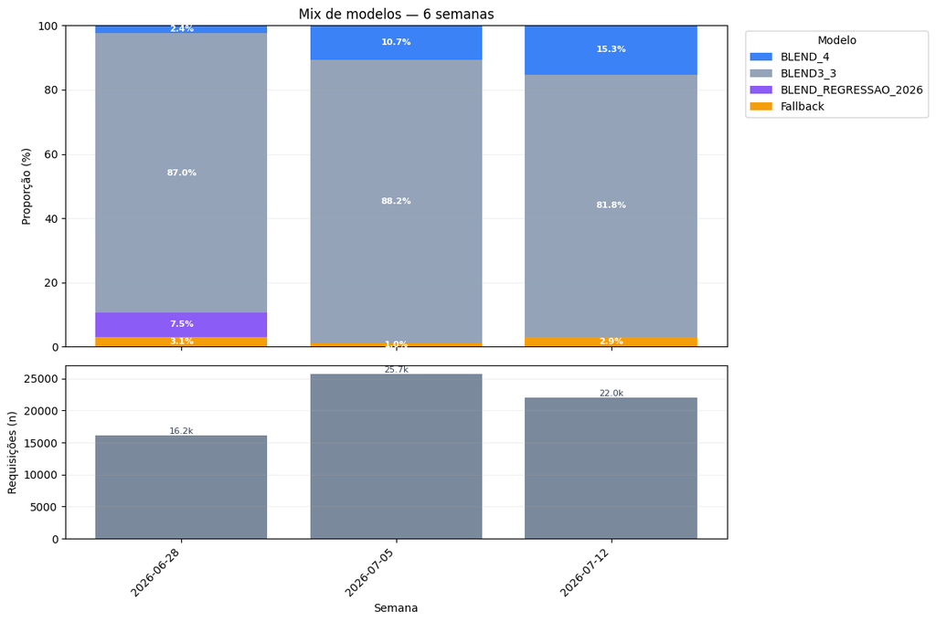

## Mix de Modelos Diário e Semanal

Nesta etapa, retiramos o público que é FALLBACK e seguimos apenas com as comparações entre os Blend's que estão em produção (Blend 3 Blend4).

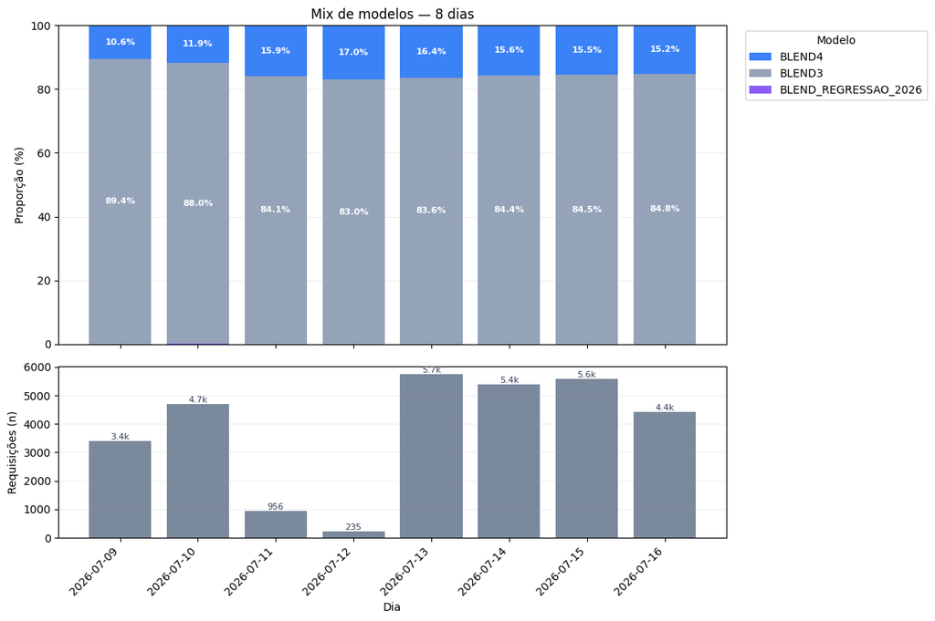

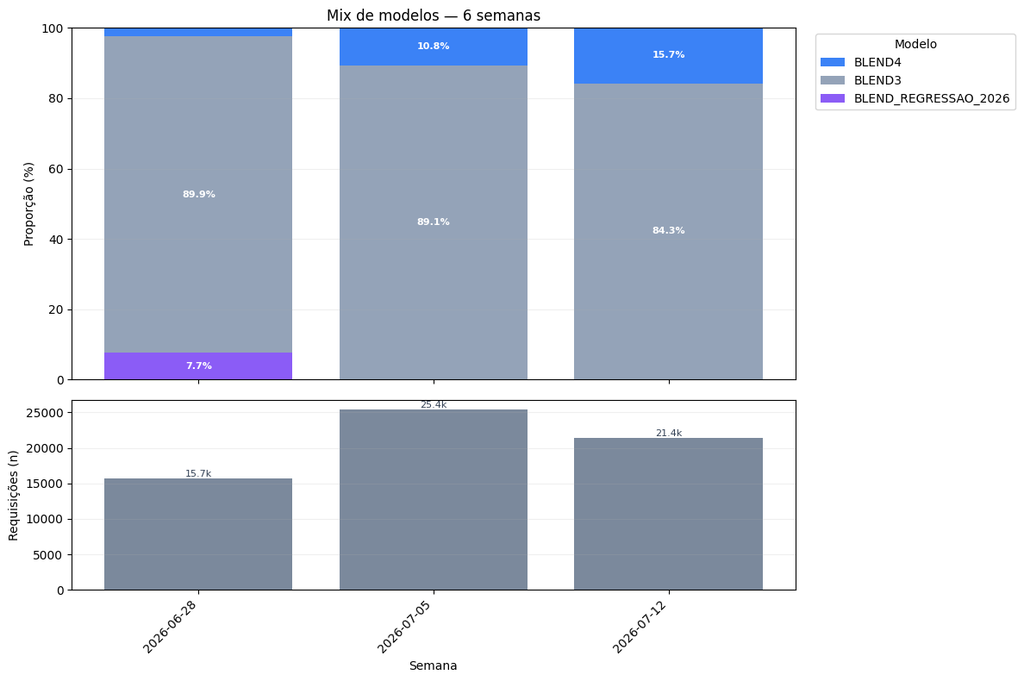

## Pré-Análise

Comparação do percentual de Aprovados, Derivados e Reprovados do Blend3 e Blend4.

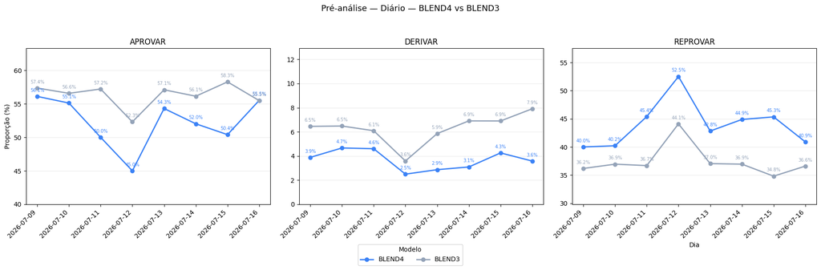

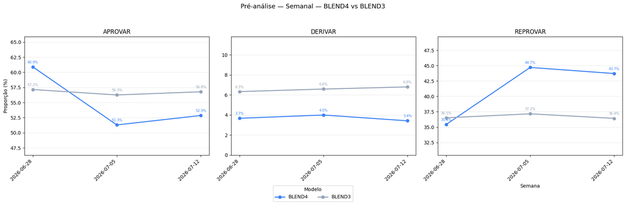

## Pré-Análise sem o Público Rating E do Blend3

Nesse caso, tiramos a elegibilidade do público que é Rating E do Blend 3.

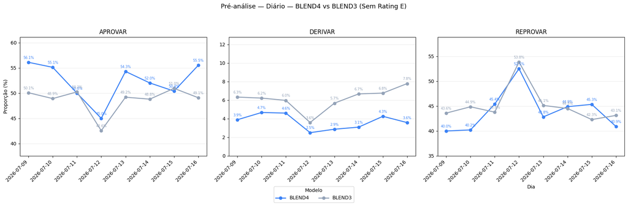

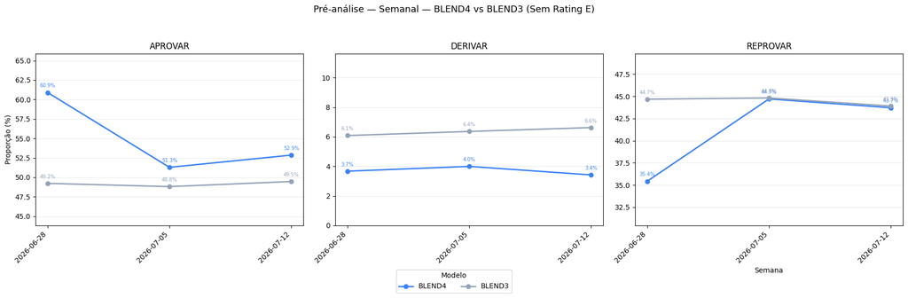

## Funil

Comparação entre Blend3 e Blend4 em relação a Elegbilidade, Envio, Atiavação e Conversão.

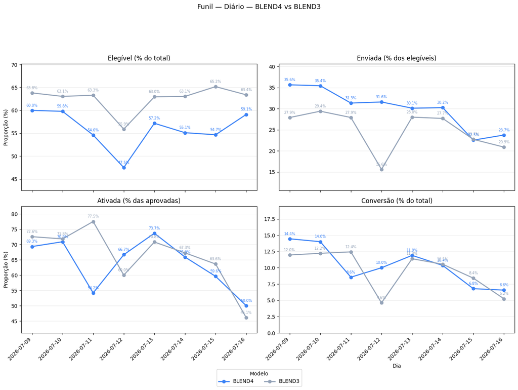

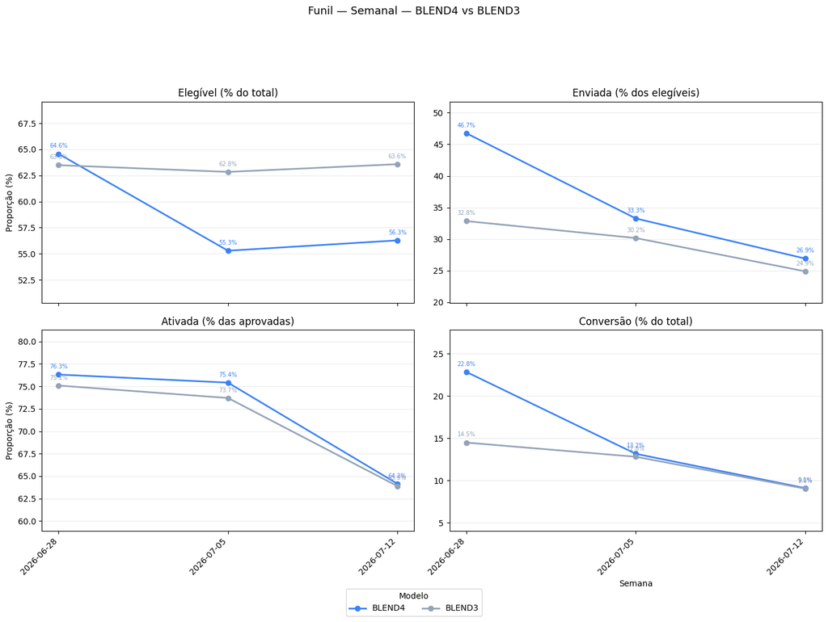

## Funil sem o Rating E do Blend3

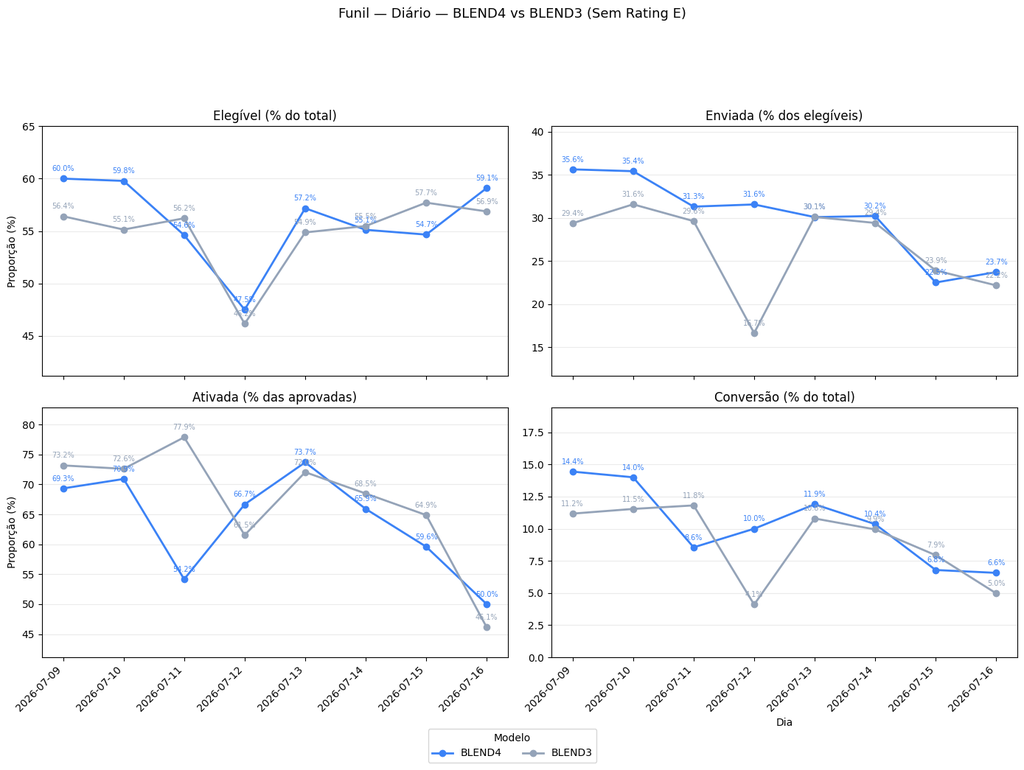

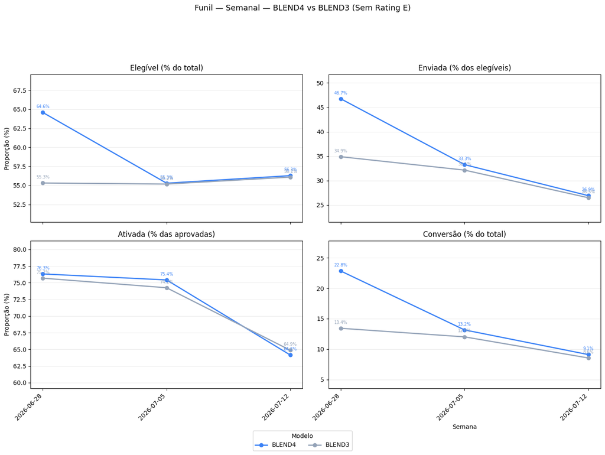

## Tabela de Conversão

Tabela de Conversão com Mix, Elegibilidade, Envio, Ativação, Conversão e Diferença de Conversão entre os modelos Blend3 e Blend4 em números e em percentual.

| bureau_nm_ajust year_week | mix BLEND3 | mix BLEND4 | elegivel BLEND3 | elegivel BLEND4 | enviada_elegivel BLEND3 | enviada_elegivel BLEND4 | ativada BLEND3 | ativada BLEND4 | conversao BLEND3 | conversao BLEND4 | diff_conversao |
| --- | --- | --- | --- | --- | --- | --- | --- | --- | --- | --- | --- |
| 2026-06-28 | 14,069 | 381 | 8,932 | 246 | 2,934 | 115 | 2,038 | 87 | 2,038 | 87 | -1,951 |
| 2026-07-05 | 22,669 | 2,751 | 14,245 | 1,521 | 4,297 | 506 | 2,904 | 362 | 2,904 | 362 | -2,542 |
| 2026-07-12 | 17,998 | 3,360 | 11,443 | 1,891 | 2,849 | 509 | 1,626 | 306 | 1,627 | 306 | -1,321 |

| bureau_nm_ajust year_week | mix BLEND3 | mix BLEND4 | %_elegivel BLEND3 | %_elegivel BLEND4 | %_enviada_elegivel BLEND3 | %_enviada_elegivel BLEND4 | %_ativada BLEND3 | %_ativada BLEND4 | %_conversao BLEND3 | %_conversao BLEND4 | diff_conversao |
| --- | --- | --- | --- | --- | --- | --- | --- | --- | --- | --- | --- |
| 2026-06-28 | 97.36% | 2.64% | 63.49% | 64.57% | 32.86% | 47.15% | 75.09% | 76.32% | 14.49% | 22.83% | +8.35 pp |
| 2026-07-05 | 89.18% | 10.82% | 62.84% | 55.29% | 30.16% | 33.27% | 73.71% | 75.42% | 12.81% | 13.16% | +0.35 pp |
| 2026-07-12 | 84.27% | 15.73% | 63.58% | 56.28% | 24.90% | 26.92% | 63.93% | 64.15% | 9.04% | 9.11% | +0.07 pp |

## Mix de Rating por Modelo: Blend 4 vs. Blend3

Mix de Rating por Modelo, considerando os 5 Rating's comparáveis.

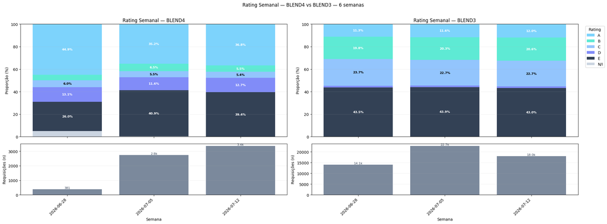

## Mix de Rating Política - Esperado vs. Produção

|  | safra | 1.A+ | 2.A | 3.B+ | 4.B | 5.C | 6.D+ | 7.D | 8.E | 9.E-BVS | volume |
| --- | --- | --- | --- | --- | --- | --- | --- | --- | --- | --- | --- |
| 11 | 2025-08 | 5.479852 | 11.252605 | 11.238394 | 11.356029 | 5.729331 | 5.888019 | 12.401314 | 26.162919 | 10.491537 | 126664 |

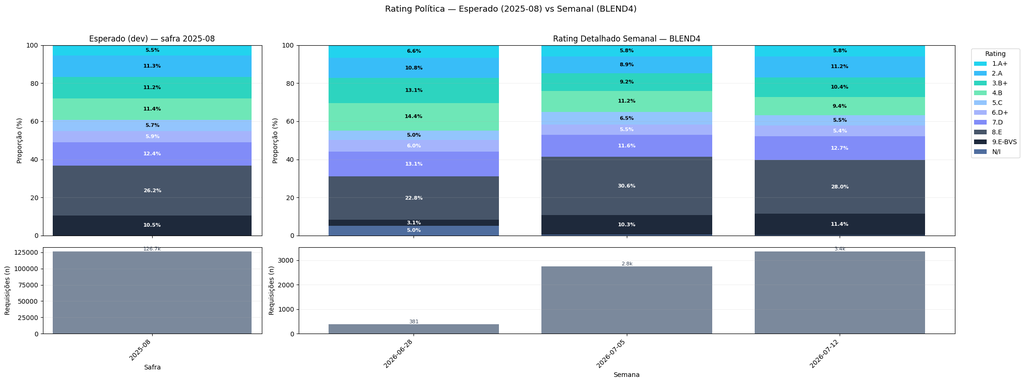

## Funil por Rating

Funil de Elegibilidade, Envio e Conversão comparado por Rating (A, B, C, D e E) em cada um dos Modelos: Blend3 e Blend4.

```
=== Elegível (%) — Semanal — por rating ===
```

| period | Blend 3 Rating A | Blend 3 Rating B | Blend 3 Rating C | Blend 3 Rating D | Blend 3 Rating E | Blend 4 Rating A | Blend 4 Rating B | Blend 4 Rating C | Blend 4 Rating D | Blend 4 Rating E |
| --- | --- | --- | --- | --- | --- | --- | --- | --- | --- | --- |
| 2026-06-28 | 99.9 | 98.9 | 98.0 | 72.3 | 18.8 | 99.4 | 100.0 | 100.0 | 66.0 | 0.0 |
| 2026-07-05 | 99.8 | 99.3 | 98.0 | 78.6 | 17.4 | 99.2 | 98.9 | 95.3 | 70.8 | 0.5 |
| 2026-07-12 | 99.9 | 99.2 | 98.1 | 79.0 | 17.4 | 99.6 | 100.0 | 96.7 | 68.1 | 0.1 |

```
=== Envio (%) — Semanal — por rating ===
```

| period | Blend 3 Rating A | Blend 3 Rating B | Blend 3 Rating C | Blend 3 Rating D | Blend 3 Rating E | Blend 4 Rating A | Blend 4 Rating B | Blend 4 Rating C | Blend 4 Rating D | Blend 4 Rating E |
| --- | --- | --- | --- | --- | --- | --- | --- | --- | --- | --- |
| 2026-06-28 | 29.8 | 34.3 | 37.5 | 47.5 | 19.0 | 44.7 | 47.4 | 47.8 | 57.6 | — |
| 2026-07-05 | 28.1 | 32.6 | 33.9 | 36.2 | 15.9 | 32.1 | 39.9 | 32.9 | 34.5 | 33.3 |
| 2026-07-12 | 19.8 | 28.1 | 28.5 | 31.8 | 13.0 | 25.8 | 30.6 | 29.9 | 27.5 | 100.0 |

```
=== Conversão (%) — Semanal — por rating ===
```

| period | Blend 3 Rating A | Blend 3 Rating B | Blend 3 Rating C | Blend 3 Rating D | Blend 3 Rating E | Blend 4 Rating A | Blend 4 Rating B | Blend 4 Rating C | Blend 4 Rating D | Blend 4 Rating E |
| --- | --- | --- | --- | --- | --- | --- | --- | --- | --- | --- |
| 2026-06-28 | 20.9 | 24.3 | 25.0 | 21.9 | 2.4 | 33.3 | 42.1 | 26.1 | 32.0 | 0.0 |
| 2026-07-05 | 20.0 | 23.0 | 21.0 | 20.1 | 1.8 | 22.9 | 30.6 | 21.3 | 16.6 | 0.1 |
| 2026-07-12 | 12.4 | 16.7 | 15.0 | 14.4 | 1.1 | 15.8 | 17.7 | 14.2 | 12.2 | 0.0 |

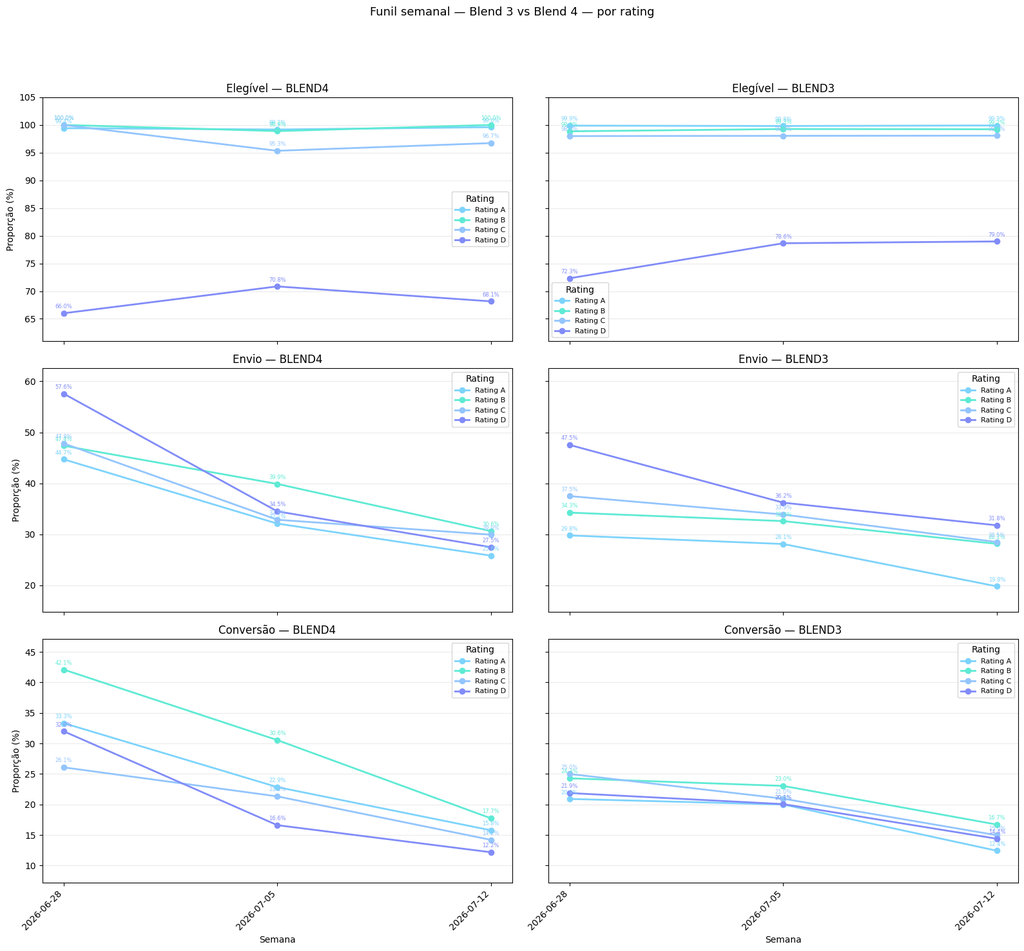

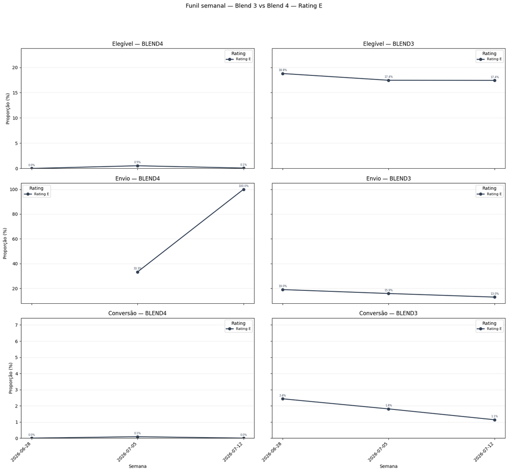

## Pré-Análise por Rating

Pré Análise (Aprovar, Derivar e Reprovar) aberto por Rating (A, B, C, D e E) e comparando os Modelos Blend3 e Blend4.

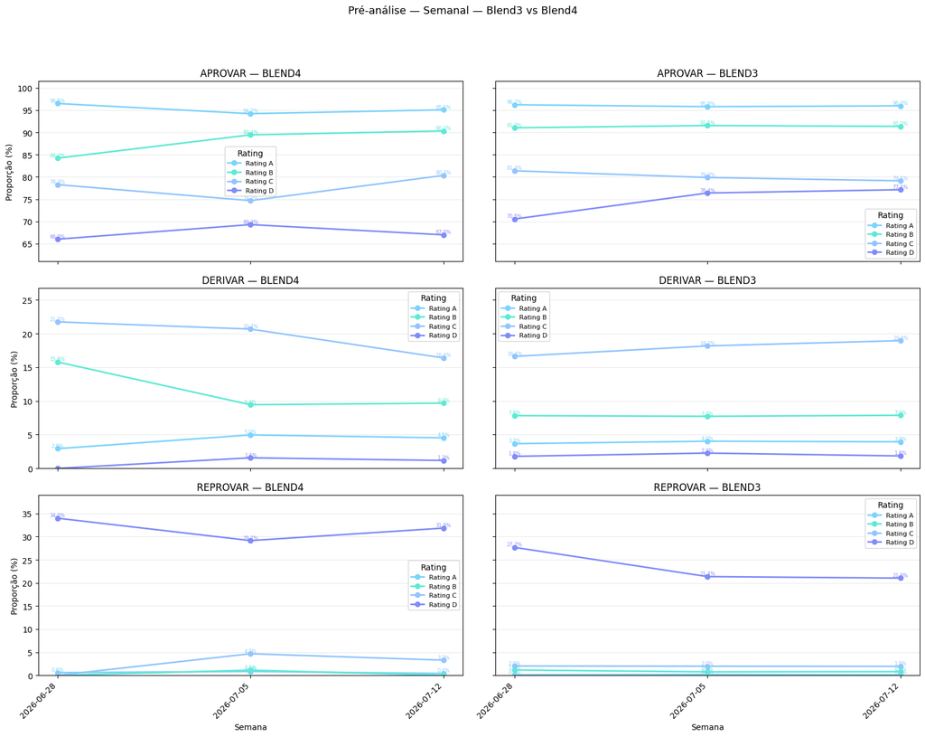

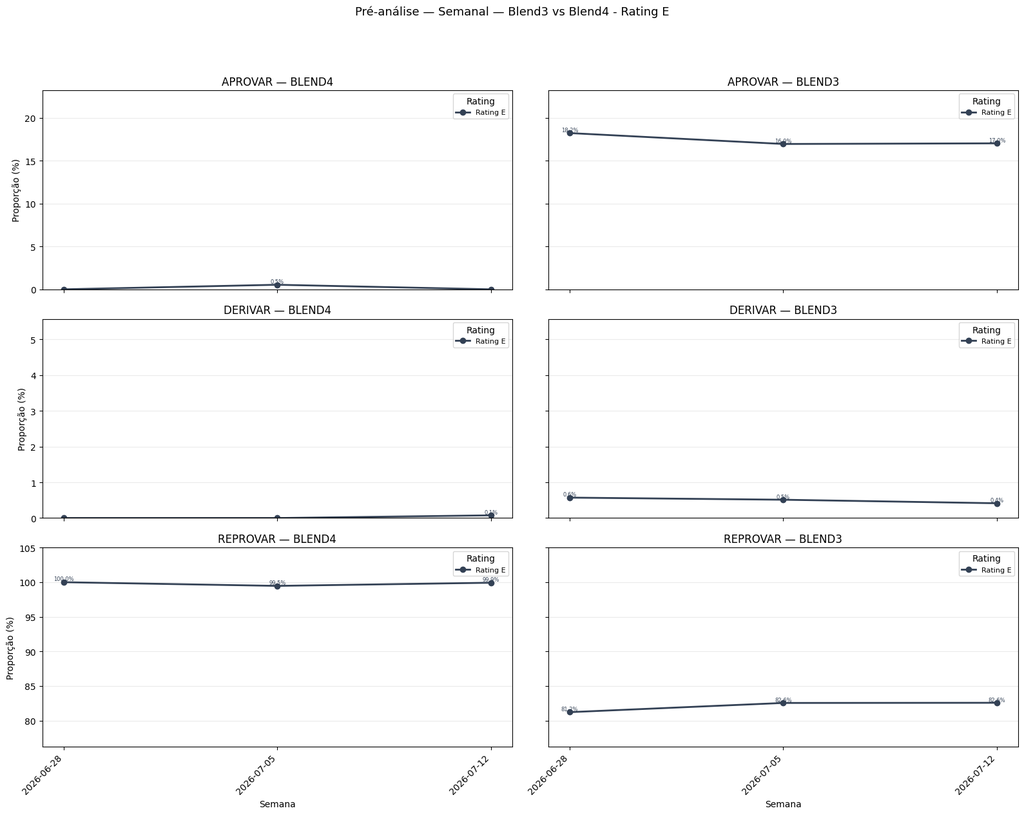